# Generalized Linear Models (GLMs)

bioX R-Summer bootcamp

8/3/2020

# Goals

We are going to spend this discussion on Generalized Linear Models, the unifying framework behind linear regression and Poisson regression that we have seen last week, and end with another extremely useful model: logistic regression.

Your mission before Monday:

- Finish the In-Class session that we started on Thursday
- Watch the following introductory video on [Generalized linear models](https://www.youtube.com/watch?v=hc06BXFYd_w).
- Go through the following lab.

# Generalized Linear Models (GLMs): A Unifying Theory

## Learning Objectives

- Determine if a probability distribution can be expressed in one-parameter exponential family form.
- Identify canonical links for distributions of one parameter exponential family form.

## One parameter exponential families

Thus far, we have expanded our repertoire of models from OLS to include Poisson regression. But in the early 1970s Nelder (1972) identified a broader class of models that generalizes the multiple linear regression we considered in the introductory chapter and are referred to as **generalized linear models (GLMs)**. All GLMs have similar forms for their likelihoods, MLEs, and variances. This makes it easier to find model estimates and their corresponding uncertainty. To determine whether a model is a GLM, we consider the following properties. When a probability formula can be written in the form below
$$\begin{equation}
f(y;\theta)=e^{[a(y)b(\theta)+c(\theta)+d(y)]} (*)
\end{equation}$$

and if the **support** (the set of possible input values) does not depend upon $\theta$, it is said to have a **one-parameter exponential family form**. We demonstrate that the Poisson distribution is a member of the one parameter exponential family by writing its probability mass function (pmf) in the form of Equation (*) and assessing its support.

### One Parameter Exponential Family: Possion

Recall we begin with
$$P(Y=y)=\frac{e^{-\lambda}{\lambda}^y}{y!}\quad \textrm{where}\quad y=0,1,2\ldots\infty$$
and consider the following useful identities for establishing exponential form:
$$a=e^{\log(a)}$$
$$a^x = e^{x\log(a)}$$
$$\log(ab)=\log(a)+\log(b)$$
$$\log\Big(\frac{a}{b}\Big)=\log(a)-\log(b)$$

Determining whether the Poisson model is a member of the one-parameter exponential family is a matter of writing the Poisson pmf in the form of Equation (*) and checking that the support does not depend upon $\lambda$. First, consider the condition concerning the support of the distribution. The set of possible values for any Poisson random variable is $y=0,1,2\ldots\infty$ which does not depend on $\lambda$. The support condition is met. Now we see if we can rewrite the probability mass function in one-parameter exponential family form.
$$\begin{align}
P(Y=y)&= {e^{-\lambda}e^{y\log \lambda}e^{-\log (y!)}} \nonumber \\
&= e^{y\log \lambda-\lambda-\log (y!)} \quad (**)
\end{align}$$
The first term in the exponent for Equation (*) must be the product of two factors, one solely a function of y, $a(y)$, and another, $b(\lambda)$, a function of $\lambda$ only. The middle term in the exponent must be a function of $\lambda$ only; no $y's$ should appear. The last term has only $y's$ and no $\lambda$. Since this appears to be the case here, we can identify the different functions in this form:
$$\begin{align}
a(y)&=y \\
b(\lambda)&=\log(\lambda) \\
c(\lambda)&=-\lambda \nonumber \\
d(y)&=-\log (y!) \\
(\#eq:diffunc)
\end{align}$$

These functions have useful interpretations in statistical theory. We won't be going into this in detail, but we will note that function $b(\lambda)$, or more generally $b(\theta)$, will be particularly helpful in GLMs. The function $b(\theta)$ is referred to as the **canonical link**. The canonical link is often a good choice to model as a linear function of the explanatory variables. That is, Poisson regression should be set up as $\log(\lambda)=\beta_0+\beta_1x_1+\beta_2x_2+\cdots$. In fact, there is a distinct advantage to modeling the canonical link as opposed to other functions of $\theta$, but it is also worth noting that other choices are possible, and at times preferred, depending upon the context of the application.

There are other benefits of identifying a response as being from a one parameter exponential family. For example, by creating an unifying theory for regression modeling, Nelder and Wedderburn made possible a common and efficient method for finding estimates of model parameters using iteratively reweighted least squares (IWLS). In addition, we can use the one parameter exponential family form to determine the expected value and standard deviation of $Y$. With statistical theory you can show that
$${\operatorname{E}}(Y) =-\frac{c'(\theta)}{b'(\theta)} \quad \textrm{and} \quad {\operatorname{Var}}(Y) =\frac{b''(\theta)c'(\theta)-c''(\theta)b'(\theta)}{[b'(\theta)]^3}$$
where differentiation is with respect to $\theta$. Verifying these results for the Poisson response:
$${\operatorname{E}}(Y)=-\frac{-1}{1/\lambda}=\lambda \quad \textrm{and} \quad {\operatorname{Var}}(Y)=\frac{1/\lambda^2}
{1/\lambda^3}=\lambda$$
We'll find that other distributions are members of the one parameter exponential family by writing their pdf or pmf in this manner and verifying the support condition. For example, we'll see that the binomial distribution meets these conditions, so it is also a member of the one parameter exponential family. The normal distribution is a special case where we have two parameters, a mean $\mu$ and standard deviation $\sigma$. If we assume, however, that one of the parameters is known, then we can show that a normal random variable is also from a one parameter exponential family.

### One parameter exponential family: Normal

Here we determine whether a normal distribution is a one parameter exponential family member. First we will need to assume that $\sigma$ is known. Next, possible values for a normal random variable range from $-\infty$ to $\infty$, so the support does not depend on $\mu$. Finally, we'll need to write the probability density function (pdf) in the one parameter exponential family form. We start with the familiar form:
$$f(y)=\frac{1}{{\sqrt{2\pi\sigma^2}}}{e^{-{(y-\mu)^2}/{(2\sigma^2)}}}$$
Even writing ${1/{\sqrt{2\pi\sigma^2}}}$ as $e^{-\log{\sigma}-\log(2\pi)/2}$ we still do not have the pdf written in one parameter exponential family form. We will first need to expand the exponent so that we have
$$f(y)=e^{[-\log{\sigma}-\log(2\pi)/2]}{e^{[-{(y^2-2y\mu +\mu^2)}/{(2\sigma^2)}]}}$$

Without loss of generality, we can assume $\sigma=1$, so that
$$f(y) \propto e^{y\mu - \frac{1}{2} \mu^2 - \frac{1}{2} y^2}$$
and $a(y)=y$, $b(\mu)=\mu$, $c(\mu)= -\frac{1}{2}\mu^2$, and $d(y) = - \frac{1}{2} y^2$.

From this result, we can see that the canonical link for a normal response is $\mu$ which is consistent with what we've been doing with OLS, since the simple linear regression model has the form:
$$\mu_{Y|X} = \beta_0 + \beta_1X.$$

## Generalized Linear Modeling

GLM theory suggests that the canonical link can be modeled as a linear combination of the explanatory variable(s). This approach unifies a number of modeling results used throughout the text. For example, likelihoods can be used to compare models in the same way for any member of the one-parameter exponential family.

We have now **generalized** our modeling to handle non-normal responses. In addition to normally distributed responses, we are able to handle Poisson responses, binomial responses, and more. Writing a pmf or pdf for a response in one parameter exponential family form reveals the canonical link which can be modeled as a linear function of the predictors. This linear function of the predictors is the last piece of the puzzle for performing generalized linear modeling. But, in fact, it is really nothing new. We already use linear combinations and the canonical link when modeling normally distributed data.

**Three Components of a GLM**

> 1. Distribution of $Y$ (e.g., Poisson)
> 2. Link Function (a function of the parameter, e.g., $\log(\lambda)$ for Poisson)
> 3. Linear Predictor (choice of predictors, e.g., $\beta_0 + \beta_1 x_1 + \beta_2 x_2 + \cdots$)

One parameter exponential family form and canonical links.

[output not shown]

Completing this table is left as an exercise (see below).

In the chapter on Poisson modeling, we provided heuristic rationale for using the $\log()$ function as our link. That is, counts would be non-negative but a linear function inevitably goes negative. By taking the logarithm of our parameter $\lambda$ we could use a linear predictor and not worry that it can take on negative values. Now we have theoretical justification for this choice, as the log is the canonical link for Poisson data. In the next chapter we encounter yet another type of response, a binary response, which calls for a different link function. Our work here suggests that we will model $\text{logit}(p)=\log\left(\frac{p}{1-p}\right)$ using a linear predictor.

[Note that **generalized linear models (GLMs)** differs from **General Linear Models**. The *general* linear model is a statistical linear model with multivariate vectors as responses. For example, each subject in a study may have their height, weight, and shoe size recorded and modeled as a function of age and sex. The response is a vector, $Y$ = (height, weight, shoe size), for each study participant. Age and sex are explanatory variables in the model. The residual is usually assumed to follow a multivariate normal distribution. If the residual is not a multivariate normal distribution, then generalized linear models may be used to relax assumptions about Y and the variance-covariance structure.]

## Exercises

1. For each distribution,
- Write the pdf in one parameter exponential form, if possible.
- Describe an example of a setting where this random variable might be used.
- Identify the canonical link function, and
- Compute $\mu = -\frac{c'(\theta)}{b'(\theta)}$ and $\sigma^2 = \frac{b''(\theta)c'(\theta)-c''(\theta)b'(\theta)}{[b'(\theta)]^3}$ and compare with known ${\operatorname{E}}(Y)$ and ${\operatorname{Var}}(Y)$.
1. Binary: Y = 1 for a success, 0 for a failure

$$p(y)=p^{y}(1-p)^{(1-y)}$$

2. Binomial (for fixed $n$): Y = number of successes in $n$ independent, identical trials

$$p(y)=\left(\begin{array} {c} n\\y \end{array}\right) p^y(1-p)^{(n-y)}$$

3. Poisson: Y = number of events occurring in a given time (or space) when the average event rate is $\lambda$ per unit of time (or space)

$$P(Y=y)=\frac{e^{-\lambda}\lambda^y}{y!}$$

4. Normal (with fixed $\sigma$ -- could set $\sigma=1$ without loss of generality)

$$f(y; \mu)=\frac{1}{\sqrt{2\pi\sigma^2}}e^{-{(y-\mu)^2}/{(2\sigma^2)}}$$

5. Normal (with fixed $\mu$ -- could set $\mu=0$ without loss of generality)

$$f(y; \sigma)=\frac{1}{\sqrt{2\pi\sigma^2}}e^{-{(y-\mu)^2}/{(2\sigma^2)}}$$

6. Exponential: Y = time spent waiting for the first event in a Poisson process with an average rate of $\lambda$ events per unit of time

$$f(y)=\lambda e^{-\lambda y}$$

7. Gamma (for fixed $r$): Y = time spent waiting for the $r^{th}$ event in a Poisson process with an average rate of $\lambda$ events per unit of time

$$f(y; \lambda) = \frac{\lambda^r}{\Gamma(r)} y^{r-1} e^{-\lambda y}$$

8. Geometric: Y = number of failures before the first success in a Bernoulli process

$$p(y)=(1-p)^{y}p$$

1. Negative Binomial (for fixed $r$): Y = number of failures prior to the $r^{th}$ success in a Bernoulli process

$$\begin{align}
p(y; r) & = \left(\begin{array} {c} y+r-1\\r-1 \end{array}\right)(1-p)^{y}p^r \nonumber \\
& = \frac{\Gamma(y+r)}{\Gamma(r)y!} (1-p)^{y}p^r \\
\end{align}$$

10. Pareto (for fixed $k$):

$$f(y; \theta)=\frac{\theta k^\theta}{y^{(\theta+1)}}\quad \textrm{for}\quad y\geq k; \theta \geq 1$$

2. Complete Table 1 containing your results of the preceding exercises.

## Exercises (for Monday)

**Question 1** A researcher B wants to predict the number of awards that a newly admitted student will earn by looking at the type of program in which the student was enrolled (vocational, general or academic) and the score of their final math exam. (Count response) Load the data at the following link: "https://stats.idre.ucla.edu/stat/data/poisson_sim.csv" and tell researcher B how we should proceed. What model should he use? What assumption should he make? How should he interpret the output?

*Solution*

```r
library(tidyverse)
```

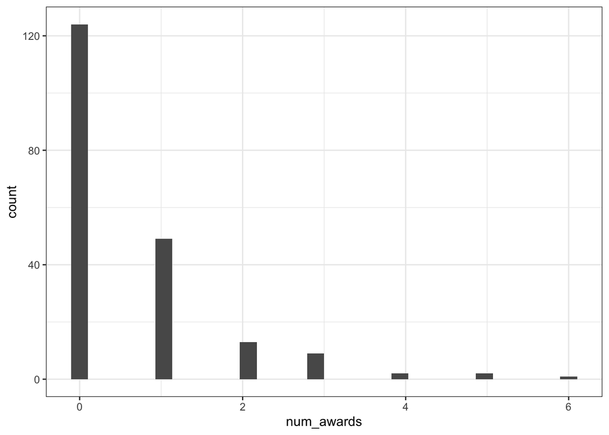

```r
p <- read.csv("https://stats.idre.ucla.edu/stat/data/poisson_sim.csv")
ggplot(p)+
  geom_histogram(aes(x=num_awards)) +
  theme_bw()
```

```r
mod <- glm(num_awards ~ prog + math, data = p, family="poisson")
print(summary(mod))
```

```
##
## Call:
## glm(formula = num_awards ~ prog + math, family = "poisson", data = p)
##
## Deviance Residuals:
##     Min       1Q   Median       3Q      Max
## -2.1840  -0.9003  -0.5891   0.3948   2.9539
##
## Coefficients:
##              Estimate Std. Error z value Pr(>|z|)
## (Intercept) -5.578057   0.676823  -8.242   <2e-16 ***
## prog         0.123273   0.163261   0.755     0.45
## math         0.086121   0.009586   8.984   <2e-16 ***
## ---
## Signif. codes:  0 '***' 0.001 '**' 0.01 '*' 0.05 '.' 0.1 ' ' 1
##
## (Dispersion parameter for poisson family taken to be 1)
##
##     Null deviance: 287.67  on 199  degrees of freedom
## Residual deviance: 203.45  on 197  degrees of freedom
## AIC: 385.51
##
## Number of Fisher Scoring iterations: 6
```

**Question 2** Suppose you want to study the length of hospital stay, in days, as a function of age, kind of health insurance and whether or not the patient died while in the hospital. Length of hospital stay is recorded as a minimum of at least one day. We have a hypothetical data file, ztp.dta with 1,493 observations. The length of hospital stay variable is stay. The variable age gives the age group from 1 to 9 which will be treated as interval in this example. The variables hmo and died are binary indicator variables for HMO insured patients and patients who died while in the hospital, respectively.

1. Look at histograms of stay broken down by hmo on the rows and died on the columns. We also include the marginal distributions. We use a log base 10 scale to approximate the canonical link function of the negative binomial distribution (natural logarithm). Comment on the plot. Is there a day that seems inflated with respect to the rest?

```r
require(foreign)
```

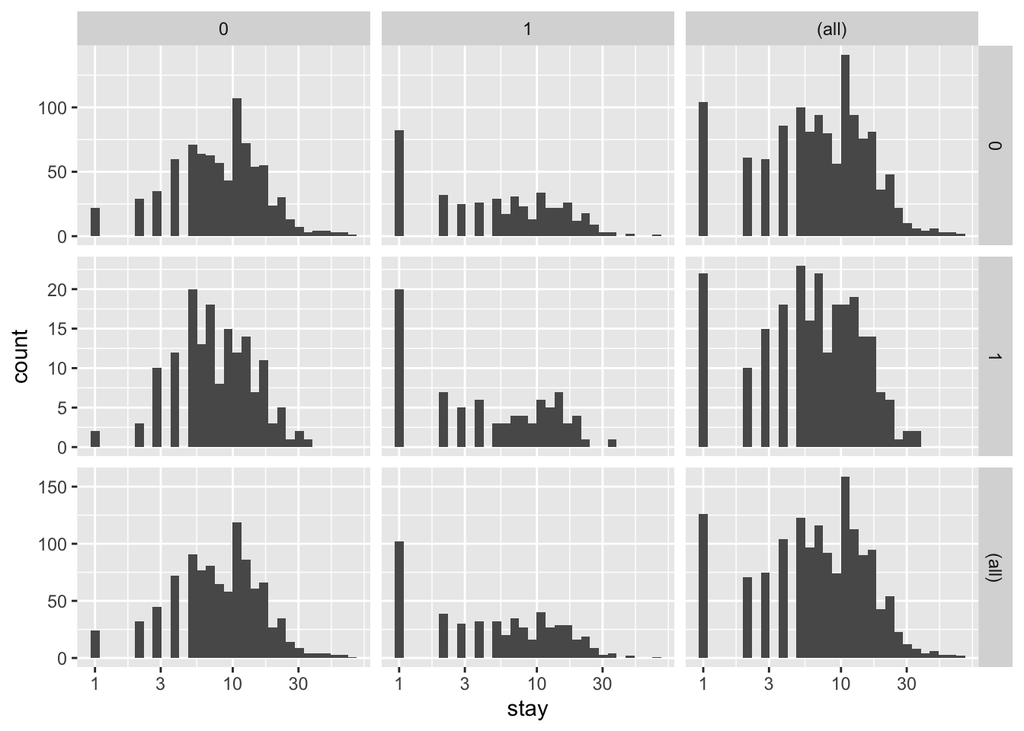

```r
require(ggplot2)
require(VGAM)
require(boot)
dat <- read.dta("https://stats.idre.ucla.edu/stat/data/ztp.dta")

ggplot(dat, aes(stay)) + geom_histogram() + scale_x_log10() + facet_grid(hmo ~
    died, margins = TRUE, scales = "free_y")
```

The distribution of length of stay does not seem to vary much across age groups. This observation from the raw data is corroborated by the relatively flat loess line.

From the histograms, it looks like the density of the distribution, does vary across levels of hmo and died, with shorter stays for those in HMOs (1) and shorter for those who did die, including what seems to be an inflated number of 1 day stays. To examine how stay varies across age groups, we can use conditional violin plots which show a kernel density estimate of the distribution of stay mirrored (hence the violin) and conditional on each age group. To further understand the raw data going into each density estimate, we add raw data on top of the violin plots with a small amount of random noise (jitter) to alleviate over plotting. Finally, to get a sense of the overall trend, we add a locally weighted regression line.

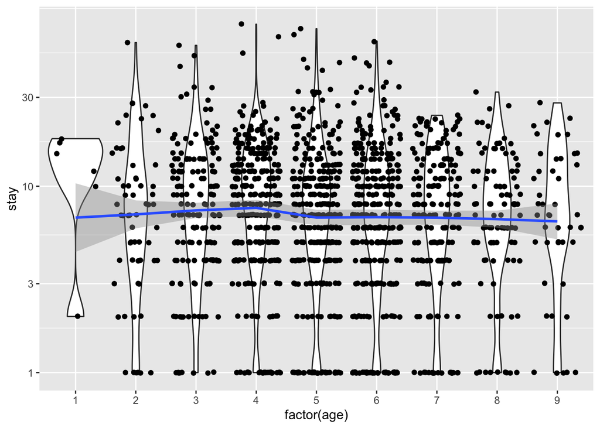

```r
ggplot(dat, aes(factor(age), stay)) +
  geom_violin() +
  geom_jitter(size=1.5) +
  scale_y_log10() +
  stat_smooth(aes(x = age, y = stay, group=1), method="loess")
```

Analysis methods you might consider Below is a list of some analysis methods you may have encountered. Some of the methods listed are quite reasonable while others have either fallen out of favor or have limitations.

- Zero-truncated Negative Binomial Regression.
- Zero-truncated Poisson Regression – Useful if you have no overdispersion.
- Poisson Regression – Ordinary Poisson regression will have difficulty with zero-truncated data. It will try to predict zero counts even though there are no zero values.
- Negative Binomial Regression – Ordinary Negative Binomial regression will have difficulty with zero-truncated data. It will try to predict zero counts even though there are no zero values.
- OLS Regression – You could try to analyze these data using OLS regression. However, count data are highly non-normal and are not well estimated by OLS regression.
2. Argue why you could use here a zero-truncated negative binomial model and model `stay ~ age + hmo + died` using the `vglm` library.

To fit the zero-truncated negative binomial model, we use the vglm function in the VGAM package. This function fits a very flexible class of models called vector generalized linear models to a wide range of assumed distributions. In our case, we believe the data come from the negative binomial distribution, but without zeros. Thus the values are strictly positive poisson, for which we use the positive negative binomial family via the posnegbinomial function passed to vglm.

```r
m1 <- vglm(stay ~ age + hmo + died, family = posnegbinomial(), data = dat)
print(summary(m1))
```

```
##
## Call:
## vglm(formula = stay ~ age + hmo + died, family = posnegbinomial(),
##     data = dat)
##
## Pearson residuals:
##                   Min      1Q  Median     3Q    Max
## loglink(munb)  -1.284 -0.6845 -0.2020 0.4504 8.2284
## loglink(size) -13.924 -0.2586  0.4217 0.7541 0.8668
##
## Coefficients:
##               Estimate Std. Error z value Pr(>|z|)
## (Intercept):1  2.40833    0.07158  33.645  < 2e-16 ***
## (Intercept):2  0.56864    0.05489  10.359  < 2e-16 ***
## age           -0.01569    0.01304  -1.204    0.229
## hmo           -0.14706    0.05922  -2.483    0.013 *
## died          -0.21777    0.04615  -4.719 2.38e-06 ***
## ---
## Signif. codes:  0 '***' 0.001 '**' 0.01 '*' 0.05 '.' 0.1 ' ' 1
##
## Names of linear predictors: loglink(munb), loglink(size)
##
## Log-likelihood: -4755.28 on 2981 degrees of freedom
##
## Number of Fisher scoring iterations: 4
##
## No Hauck-Donner effect found in any of the estimates
```